# CS50R Notes

# 3. Applying Functions

When writing code, you will often have certain procedures that will need to be repeated multiple times in a script. Rather than rewriting this many times, a better method is to define a function, then call it later on when its needed. In R, this is done with `function()`. Here, we’ll use the votes data from earlier and create a function for this that can be reused/adapted to different data. The function will take a `prompt` argument and ask the user for an input with this.

Within functions, the variables used within them are not within the global scope, meaning that variables in a function are not available outside of them. `return()` is the way around this and allows us to pass objects to an outside scope. In the function below, the variable `votes` is defined in the function, so when we run `get_votes()`, this variable is created in the function’s scope, but not the global one. Essentially, this makes it a temporary variable that only exists while the function is actively being used in our code, unless it gets returned.

Note that `return()` returns a specified value, but by default R will return the last computed value. While `return()` isn’t needed, for longer functions it could be better to explicitly return something especially with branching conditional procedures. In some other languages, the default return value for functions is an equivalent to `NA`, like `None` in Python, while in others its a value indicating if the function was successful (like `0` in C).

```r
#Define The get_votes
get_votes <- function() {
  votes <-  as.integer(readline("Enter Votes: "))
  return(votes)
}

#Call Function
mario <- get_votes()
1
peach <- get_votes()
2
bowser <- get_votes()
3
#Inputs: 3,2,1
```

What if the user doesn’t input a prompt for this function? In this instance, if no value is provided, the user will get an error, which is good if you want to enforce using a prompt. To prevent this, you can give a default value to the `prompt` argument that will show when no value is provided.

```r
#Define The get_votes
get_votes <- function(prompt = "Enter Votes: ") {
  votes <-  as.integer(readline(prompt))
  return(votes)
}

mario <- get_votes()
300
peach <- get_votes()
150
bowser <- get_votes()
100
#Inputs: 300, 150, 100
```

When parameters are added to a function, there are two ways to use them in a function. You can assign parameters positionally by putting them in the same order as they’re defined in the function or using keywords in the format: `func_var = "my_value"`. For the above function, you could assign “`Mario:`” as a prompt as either of the following: `get_votes("Mario: ")` (positionally), `get_votes(prompt = "Mario: ")`.

When writing functions, its tempting put them together, assuming that the user will always know what to do with them. This is rarely the case and relies on you writing good documentation, the user reading that documentation, and no other weird circumstances occurring. To prevent erroneous mistakes in your functions, its important to program defensively; assume the user will make mistakes and handle potential errors and bugs.

For the `get_votes()` functions, we run into an issue with input values whenever the user provides a non-integer value. `as.integer()` turns non-integer values into `NA` values through coercion, so we’ll want to handle this before it gets assigned and tell the user what went wrong. When `as.integer()` runs, in our function some exceptions get raised which we won’t want in our actual function since we’re handling the issue they raise. To prevent these from showing, we can use `suppressWarning()`.

```r
get_votes <- function(prompt = "Enter Votes: ") {
  votes <-  suppressWarning(as.integer(readline(prompt)))
  if (is.na(votes)) {
    stop()
  } else {
    return(votes)
    }
}
```

```r
help("stop")
```

## Iterating with Loops

Loops allow use to repeat the same code multiple times using the same or similar procedures. This prevents repeating code, especially for repetitive processes that can instead by iterative.

Ways to loop in R include `repeat`, `while`, and `for`. `repeat` is a keyword that repeats a specific process indefinitely unless the keyword `break` is used. `while` loops while a certain condition is met. `for` repeats a process but only for a specific number of times based on an iterable object.

```r
#Using repeat
cat("Using repeat:\n")
```

```
Using repeat:
```

```r
i <- 3
repeat {
  cat("quack!\n")
  i <- i - 1
  if (i == 0) {
    break
  }
}
```

```
quack!
quack!
quack!
```

```r
#Using while
cat("\nUsing while:\n")
```

```
Using while:
```

```r
i <- 3
while (i != 0) {
  cat("quack!\n")
  i <- i - 1
}
```

```
quack!
quack!
quack!
```

```r
#Using for
cat("\nUsing for:\n")
```

```
Using for:
```

```r
n <- 3

for (i in 1:n) {
  cat("quack!\n")
}
```

```
quack!
quack!
quack!
```

One way to use loops is re-prompting a user. With the `get_votes()` function from before, we can use `repeat` to re-prompt the user until they provide a valid number. Then, we can use a `for` loop to iterate through a list of candidates, ask for their votes, and count them.

```r
#Define Function
get_votes <- function(prompt = "Enter Votes: ") {
  repeat {
    votes <- suppressWarnings(as.integer(readline(prompt)))
    if (!is.na(votes)) {
      return(votes)
    }
  }
}

#Iterate through Candidates
total <- 0
candidates <- c("Mario","Peach","Bowser")

for (i in candidates) {
  votes <- get_votes(paste0(i, ": "))
  total <- total + votes
}
100
50
25

#Print Total
cat(total)
```

```
175
```

Iterating can also be useful within dataframes. For example, with the `votes.csv` dataset, you could have row names that are the name of each candidate, rather than a column for the candidates. In this format, you can iterate using row indices to get total votes by candidate.

```r
#Import New Votes Dataset
votes2 <- read.csv("data/votes2.csv")
View(votes2)
```

```r
#Iterate and Get Sum
total_votes <- c()
for (candidate in rownames(votes2)) {
  total_votes[candidate] <- sum(votes2[candidate,])
}

#Show total_votes
cat(total_votes)
```

```
100 150 120
```

## Using Apply

When iterating over dataframes in this way, there is a special method for applying the same function over and over. The `apply()` function lets us apply functions across rows or columns. Apply takes three main arguments: a dataframe, `MARGIN` indicating if you want to apply across rows (`1`) or columns (`2`) , and `FUN` indicating what function to apply.

```r
remove(votes)
apply(votes2, MARGIN = 1, FUN = sum)
```

```
 Mario  Peach Bowser
   100    150    120
```

# 4. Tidying Data

## Installing and Using Packages

Packages are a way to redistribute code for others to use, which is often extremely helpful when multiple people are doing the same process and can simply reuse previously created functions. With R, most packages are stored on and can be downloaded from CRAN (the Comprehensive R Archive Network). For data manipulation (“tidying”) and visualization, R has a few packages that are extremely commonly used for this purpose including `dplyr`, `ggplot2`, `stringr` and `tidyr`. These specific packages collectively make up part of the “tidyverse”.

To install packages, we use `install.packages()` with the name of the package. This uses CRAN to find the package, but if a package isn’t in CRAN or you need a specialized version of it, they can also be installed directly from files. To load a package into your workspace, the function `library()` is used. The reason this isn’t called “package” is that the library is where R stores packages locally, so you’re accessing the library and looking for a specific package rather than directly accessing it.

Below, the package tidyverse is installed and dplyr is loaded into our workspace. Because tidyverse is a collection of packages, it cannot be accessed with `library()`, but its components such as dplyr can be.

```r
install.packages("tidyverse")
```

```r
library(dplyr)
```

dplyr gives some new functions that can be used to quickly and with a high precision pull apart, subset, and manipulate data. The main functions from this package for this purpose include: `select()`, `filter()`, `arrange()`, `distinct()`, `group_by()`, and `summarize()`.

## dplyr - Selecting, Filtering, and Sorting

Within dplyr, there are some pre-made datasets that can be used for example data analysis. One of these (`storms`) is shows storm track data from NOAA between 1975 and 2021. This data is stored as a tibble, which is a specialized data format used by dplyr that is similar to a dataframe, but has other elements. For example, these can be printed “prettier” in the console and give the type of data for individual columns.

```r
storms
```

| name | year | month | day | hour | lat | long | status | category | wind | pressure | tropicalstorm_force_diameter | hurricane_force_diameter |
| --- | --- | --- | --- | --- | --- | --- | --- | --- | --- | --- | --- | --- |
| Amy | 1975 | 6 | 27 | 0 | 27.5 | -79.0 | tropical depression | NA | 25 | 1013 | NA | NA |
| Amy | 1975 | 6 | 27 | 6 | 28.5 | -79.0 | tropical depression | NA | 25 | 1013 | NA | NA |
| Amy | 1975 | 6 | 27 | 12 | 29.5 | -79.0 | tropical depression | NA | 25 | 1013 | NA | NA |
| Amy | 1975 | 6 | 27 | 18 | 30.5 | -79.0 | tropical depression | NA | 25 | 1013 | NA | NA |
| Amy | 1975 | 6 | 28 | 0 | 31.5 | -78.8 | tropical depression | NA | 25 | 1012 | NA | NA |
| Amy | 1975 | 6 | 28 | 6 | 32.4 | -78.7 | tropical depression | NA | 25 | 1012 | NA | NA |
| Amy | 1975 | 6 | 28 | 12 | 33.3 | -78.0 | tropical depression | NA | 25 | 1011 | NA | NA |
| Amy | 1975 | 6 | 28 | 18 | 34.0 | -77.0 | tropical depression | NA | 30 | 1006 | NA | NA |
| Amy | 1975 | 6 | 29 | 0 | 34.4 | -75.8 | tropical storm | NA | 35 | 1004 | NA | NA |
| Amy | 1975 | 6 | 29 | 6 | 34.0 | -74.8 | tropical storm | NA | 40 | 1002 | NA | NA |

[output cut: 990 more lines]

With this dataset, we’ll look at hurricanes and their relative force compared to each other.

When using packages, you can directly use their functions like normal or can indicate what package it’s from using two colons (`package::function()` this syntax can be useful if your script requires many packages with some having the same names. Here, we’ll use `select()` in this format to select specific columns of data to work with. This function uses a dataframe, tibble, etc. as its first argument, then a vector of column names as its second. In this instance, we want to specify columns to drop, rather than keep, so we’ll add ! in front of the vector to indicate we want to keep columns that are not those specified. Since some of the column names are long, we’ll also separate arguments into their own lines. As long as the commas are preserve, you can simply put arguments onto their own line for better readability.

```r
dplyr::select(
  storms,
  !c(
    lat,
    long,
    pressure,
    tropicalstorm_force_diameter,
    hurricane_force_diameter)
)
```

| name | year | month | day | hour | status | category | wind |
| --- | --- | --- | --- | --- | --- | --- | --- |
| Amy | 1975 | 6 | 27 | 0 | tropical depression | NA | 25 |
| Amy | 1975 | 6 | 27 | 6 | tropical depression | NA | 25 |
| Amy | 1975 | 6 | 27 | 12 | tropical depression | NA | 25 |
| Amy | 1975 | 6 | 27 | 18 | tropical depression | NA | 25 |
| Amy | 1975 | 6 | 28 | 0 | tropical depression | NA | 25 |
| Amy | 1975 | 6 | 28 | 6 | tropical depression | NA | 25 |
| Amy | 1975 | 6 | 28 | 12 | tropical depression | NA | 25 |
| Amy | 1975 | 6 | 28 | 18 | tropical depression | NA | 30 |
| Amy | 1975 | 6 | 29 | 0 | tropical storm | NA | 35 |
| Amy | 1975 | 6 | 29 | 6 | tropical storm | NA | 40 |

[output cut: 990 more lines]

This method is a bit “wordy”, which we often want to avoid when working with a large number of rows or columns while subsetting. Luckily, dplyr comes with some helper functions that can make subsetting much easier, namely `contains()`, `ends_with()`, and `starts_with()`.

```r
dplyr::select(
  storms,
  !c(
    lat,
    long,
    pressure,
    ends_with("diameter")
    )
  )
```

| name | year | month | day | hour | status | category | wind |
| --- | --- | --- | --- | --- | --- | --- | --- |
| Amy | 1975 | 6 | 27 | 0 | tropical depression | NA | 25 |
| Amy | 1975 | 6 | 27 | 6 | tropical depression | NA | 25 |
| Amy | 1975 | 6 | 27 | 12 | tropical depression | NA | 25 |
| Amy | 1975 | 6 | 27 | 18 | tropical depression | NA | 25 |
| Amy | 1975 | 6 | 28 | 0 | tropical depression | NA | 25 |
| Amy | 1975 | 6 | 28 | 6 | tropical depression | NA | 25 |
| Amy | 1975 | 6 | 28 | 12 | tropical depression | NA | 25 |
| Amy | 1975 | 6 | 28 | 18 | tropical depression | NA | 30 |
| Amy | 1975 | 6 | 29 | 0 | tropical storm | NA | 35 |
| Amy | 1975 | 6 | 29 | 6 | tropical storm | NA | 40 |

[output cut: 990 more lines]

Now that columns have been removed, you will also want to subset the rows of your data to only get specific values. Four our purposes, we’ll use `filter()`. This function uses logical expressions to determine what to remove and keep. Below, we’ve added `hurricanes` as an object to store our subsetted data. To avoid doing this, you can instead add the `select()` function to `filter()` in place of the data object. For this instance that would be fine, but for more complex filtering, things can get messy quickly.

```r
hurricanes <- dplyr::select(
  storms,
  !c(
    lat,
    long,
    pressure,
    ends_with("diameter")
    )
  )

hurricanes <- dplyr::filter(
  storms,
  status == "hurricane"
)

hurricanes
```

| name | year | month | day | hour | lat | long | status | category | wind | pressure | tropicalstorm_force_diameter | hurricane_force_diameter |
| --- | --- | --- | --- | --- | --- | --- | --- | --- | --- | --- | --- | --- |
| Blanche | 1975 | 7 | 27 | 6 | 35.9 | -70.0 | hurricane | 1 | 65 | 987 | NA | NA |
| Blanche | 1975 | 7 | 27 | 12 | 36.9 | -69.0 | hurricane | 1 | 70 | 984 | NA | NA |
| Blanche | 1975 | 7 | 27 | 18 | 37.9 | -68.0 | hurricane | 1 | 75 | 981 | NA | NA |
| Blanche | 1975 | 7 | 28 | 0 | 39.3 | -67.2 | hurricane | 1 | 75 | 980 | NA | NA |
| Blanche | 1975 | 7 | 28 | 6 | 41.2 | -66.4 | hurricane | 1 | 70 | 980 | NA | NA |
| Caroline | 1975 | 8 | 30 | 0 | 23.3 | -94.2 | hurricane | 1 | 65 | 990 | NA | NA |
| Caroline | 1975 | 8 | 30 | 6 | 23.5 | -94.9 | hurricane | 1 | 65 | 990 | NA | NA |
| Caroline | 1975 | 8 | 30 | 12 | 23.7 | -95.6 | hurricane | 1 | 65 | 989 | NA | NA |
| Caroline | 1975 | 8 | 30 | 18 | 23.8 | -96.3 | hurricane | 1 | 70 | 987 | NA | NA |
| Caroline | 1975 | 8 | 31 | 0 | 24.0 | -97.0 | hurricane | 3 | 100 | 973 | NA | NA |

[output cut: 990 more lines]

An alternative to this is with the pipe operator. This allows you to “pipe” a value from a function on the left to the first argument of a function on the right. There are two version of this operator: `%>%`, a built-in operator that was incorporated into R in the past and `|>`, a more modern version. For most purposes, these are functionally the same, but advanced users may have specific uses for each.

Note that pipe operators let you exclude the first argument of the function, so below it looks like `select()` now uses the columns as its first argument and `filter()` uses its expression as its first argument.

```r
#Filter and Select with Pipes
storms |>
  select(!c(lat,long,pressure,ends_with("diameter"))) |>
  filter(status == "hurricane")
```

Some other functions we can use with pipe operators include `arrange()`, which allows you to sort by values in a column. By default this sorts lowest to highest, but you can use `desc()` to sort from highest to lowest. You can also sort using multiple columns by providing both. This will first sort by the first column given, then for any values that are the same in the first column, sort that subset by the second column.

In addition to `arrange()` you can also use `distinct()` to remove duplicate names. In this data, each storm was measured at multiple points in their path, leaving duplicate pieces of data for each. We also have some storms that share names such as the two hurricanes in 1979 and 1985 named Ana. To keep one value for each of these storms, you can provide the `name` and `year` column. This will only remove any rows where the name AND year match a previous record. By default `distinct()` only returns the filtered columns, so you’ll need to set the argument `.keep.all` to `TRUE`.

```r
#Select, Filter, Arrange, and Distinct
hurricanes <- storms |>
  select(!c(lat,long,pressure,ends_with("diameter"))) |>
  filter(status == "hurricane") |>
  arrange(desc(wind), name) |>
  distinct(name, year, .keep_all = TRUE)
```

After filtering your data, you may want to save it more permanently than as an object in RStudio using `write.csv()`. Since with files you do need to worry about storage space, we’ll use the pipe operator here to remove all but three columns, then pipe that into our write function.

```r
#Write to CSV
hurricanes |>
  select(c(year,name, wind)) |>
  write.csv("data/hurricanes.csv",row.names = FALSE)
```

```r
#Import Data
hurricanes <- read.csv("data/hurricanes.csv")
```

## dplyr - Grouping and Summarizing

Often, data will need to be grouped based on a specific piece of data. For example, you may want to use grouping by year to find what years had the highest wind speed and give the hurricane with the highest speed for that year.

To accomplish this, you’ll need to use the `group_by()` function to actually group the data, then `slice_head()` to show only the first value in each group. Similar to `slice_head()`, there are similar functions to cut up data with `group_by()`: `slice_tail()` for the last value, `slice_max()` for the maximum value, and `slice_min()` for the minimum value.

```r
#Groupby, Sort, and Slice
hurricanes |>
  group_by(year) |>
  arrange(desc(wind)) |>
  slice_head()
```

| year | name | wind |
| --- | --- | --- |
| 1975 | Gladys | 120 |
| 1976 | Belle | 105 |
| 1977 | Anita | 150 |
| 1978 | Ella | 120 |
| 1979 | David | 150 |
| 1980 | Allen | 165 |
| 1981 | Harvey | 115 |
| 1982 | Debby | 115 |
| 1983 | Alicia | 100 |
| 1984 | Diana | 115 |

[output cut: 38 more lines]

```r
#Groupby and Slice/Sort
hurricanes |>
  group_by(year) |>
  slice_max(order_by = wind)
```

| year | name | wind |
| --- | --- | --- |
| 1975 | Gladys | 120 |
| 1976 | Belle | 105 |
| 1977 | Anita | 150 |
| 1978 | Ella | 120 |
| 1979 | David | 150 |
| 1980 | Allen | 165 |
| 1981 | Harvey | 115 |
| 1982 | Debby | 115 |
| 1983 | Alicia | 100 |
| 1984 | Diana | 115 |

[output cut: 45 more lines]

After figuring out what years had the highest wind speeds, you might also want to see if that relates to the number of storms in each year. To do this, you can use `summarize()`, which summarizes values across rows based on their grouped values. We can input the function `n()` to this to create a count for each year in a new column. By default, `summarize()` only returns the grouped columns.

```r
#Groupby and Summarize
hurricanes |>
  group_by(year) |>
  summarize(count = n())
```

| year | count |
| --- | --- |
| 1975 | 6 |
| 1976 | 6 |
| 1977 | 5 |
| 1978 | 5 |
| 1979 | 5 |
| 1980 | 9 |
| 1981 | 7 |
| 1982 | 2 |
| 1983 | 3 |
| 1984 | 5 |

[output cut: 38 more lines]

To un-group your values, the function `ungroup()` can be used. This will return the tibble to a flat format.

## tidyr - Normalizing Data

Often, when working with data from other sources, the information you want to use won’t be “tidy.” That is, you may find erroneous `NA` values, errors with data entry, weird data structures, etc.

Sometimes, you may have a dataset where a single column represents two pieces of data that need to be separated out. In the students dataset, you’ll see that there is an `attribute` column telling what the value of a `value` column means.

```r
library(tidyr)
```

```r
#Import Data
students <- read.csv("data/students.csv")
View(students)
```

tidyr can be used to clean up data with incorrect structures like the one above. The function `pivot_wider()` allows us to reformat one column into new columns based on the values in another. For this example, the argument `id_cols` specifies what column will be used to identify records, i.e., new rows will be created with this as the shared value between them. The `names_from` argument specifies where the new column name will come from and `values_from` specifies where we’ll get values for those columns. There’s also another similar function called `pivot_longer()` which converts from columns to rows.

```r
#Pivot
students <- pivot_wider(
  students,
  id_cols = student,
  names_from = attribute,
  values_from = value
  )

#Fix GPA DType
students$GPA <- as.numeric(students$GPA)

#Find GPA by Major
students |>
  group_by(major) |>
  summarize(GPA = mean(GPA, na.rm = TRUE))
```

| major | GPA |
| --- | --- |
| Computer Science | 3.5 |
| Data Science | 3.8 |
| Statistics | 3.0 |

## stringr - Working With Strings

Data can sometimes have a variety of possible values within them that you may want to summarize. A common issue is that strings are often input in different ways by different people. For example, when surveying for a person’s favorite show, they may use a short name, full name, different spacing, different punctuation, etc. To deal with this, tidyverse includes the stringr package, which focuses around manipulating string varaibles.

```r
library(stringr)
```

```r
#Import Data
shows <- read.csv("data/shows.csv")

#View Summarized Data by Show
shows |>
  group_by(show) |>
  summarize(votes = n()) |>
  ungroup() |>
  arrange(desc(votes))
```

| show | votes |
| --- | --- |
| Arthur | 9 |
| Spongebob Squarepants | 8 |
| Avatar: The Last Airbender | 6 |
| Phineas and Ferb | 4 |
| Ben 10 | 3 |
| Jimmy Neutron | 3 |
| Fairly Oddparents | 2 |
| Kim Possible | 2 |
| Scooby Doo | 2 |
| Avatar: The Last Airbender | 1 |

[output cut: 10 more lines]

To get strings into a format where their names are matching, we’ll need to use a variety of functions. The first change we can make is removing extra spaces using the `str_trim()` and `str_squish()` functions. Both functions remove spaces from the beginning and end, with `str_trim()` beign able to specify which end or both ends. `str_squish()` cannot specify an end and also replaces and areas with multiple spaces with a single space.

To standardize the case of our text, we can used `str_to_lower()` (convert to lowercase), `str_to_upper()` (convert to uppercase), or `str_to_title()` (convert to title case. For this case, since we want the names of our shows to look mostly the same, we will want to use `str_to_title()`.

Finally, to standardize the names with subtitles in them, we’ll want to look for a substring of our basic show name in our dataset to see if any match. For this, we can use `str_detect()`, which looks for a specific substring in a set of data. When using this method, its possible to find and replace strings you didn’t intend to. For example, “Avatar” is also a movie, so searching for this substring in a database that includes shows and movies would likely create some issues.

```r
#Squish and Title Case
shows$show <- shows$show |>
  str_squish() |>
  str_to_title()

#Check Substrings
shows$show[str_detect(shows$show, "Avatar")] <- "Avatar: The Last Airbender"

#View Summarized Data by Show
shows |>
  group_by(show) |>
  summarize(votes = n()) |>
  ungroup() |>
  arrange(desc(votes))
```

| show | votes |
| --- | --- |
| Avatar: The Last Airbender | 11 |
| Arthur | 9 |
| Spongebob Squarepants | 8 |
| Phineas And Ferb | 7 |
| Jimmy Neutron | 4 |
| Ben 10 | 3 |
| Fairly Oddparents | 2 |
| Kim Possible | 2 |
| Scooby Doo | 2 |
| Hannah Montana | 1 |

[output cut: 1 more lines]

# 5. Visualizing Data

Data can be visualized in a variety of ways, both for exploratory analyses and final products. The type of data you have and how you want others to interpret the data will determine how data is visualized. In R, the main way that data is visualized is with the ggplot2 package.

```r
#Load ggplot2 to Workspace
library(ggplot2)
```

```r
#Load Data
votes <- read.csv("data/votes.csv")

#Create total votes column
votes$votes <- votes$poll + votes$mail
View(votes)
```

Plots made with ggplot2 are primarily done with the function `ggplot()`, which has a wide variety of formatting arguments/options. ggplot2 has a special syntax compared to most other packages, with `+` allowing you to add configuration options to plots, overwriting the normal behavior of addition. These additional values added with `+` are called layers.

The basic components of a plot are specified within the `ggplot()` function: your data (usually as a dataframe) is specified with the `data` argument (or first positional argument), and the `aes` argument is used to specify axes and aesthetic values.

For a basic bar plot, we can specify our data, axes, and add the `geom_col()` function.

[figure not shown]

```r
ggplot(data = votes, aes(x = candidate, y = votes)) +
  geom_col()
```

## Graph Styling

In the above plot, the x-axis is ordered alphabetically. By default, ggplot2 will sort categorical variables, rather than following the order it appears in a dataframe. To change the appears of this plot, we can add more layers to our `ggplot()` function. These can be added in any order, but there are some conventions generally accepted for writing code for ggplot2 graphs. The general order used is: `ggplot()` (your base), geometry (ex: `geom_col()`), scales, labels, anything other styling, then themes.

The names of labels can also be changed. By default, column labels are the same as column names, which often is not ideal due to the limits on spaces or capitalization used in them. To change these, the `labs()` function is added added as a layer.

Color is another major aspect of plots, which can be changed using `aes()` in the geometry function (`geom_col()` here) with the argument `fill`. This gives your columns essentially random colors and also creates a legend for your columns and their colors. When working with colors, making them accessible is usually a concern, so using the Viridis scale can be a quick way to address this. For this is done as an additional layer on your plot, with different functions for each data type (such as `scale_file_viridis_d()` for discrete variables). This function is also a potential method for renaming the legend with the `name` argument. To remove the legend, you can also add the `show.legend` parameter to the geometry’s `aes()` function, and set it to `FALSE`.

Similar to colors, there are also themes for layers. The default theme includes a grey background that isn’t generally preferred. These theme functions all begin with “theme_” and are generally added as the last layer. Most “official-looking” graphs will use the minimalistic classic theme with `theme_classic()`.

Below, the plot created is assigned to an object, `p`. To show this plot within a notebook chunk, the `show()` function can be used. This plot object can still be modified later on with additional arguments in place of the standard `ggplot()` function.

[figure not shown]

```r
p <- ggplot(data = votes, aes(x = candidate, y = votes)) +
  geom_col(aes(fill = candidate)) +
  scale_y_continuous(limits = c(0, 250)) +
  scale_fill_viridis_d(name = "Candidate") +
  labs(x = "Votes", y = "Candidate", title = "Election Results") +
  theme_classic()

show(p)
```

## Saving Plots

Plots can be saved to an image using `ggsave()`. You can customize a variety of parameters for your plot image, but mainly need to specify the file path to save to, what plot to save, and the size information.

```r
ggsave(filename = "plots/votes.png",plot = p,
       width = 1200, height = 900, units = "px")
```

## Other Common Ways to Represent Data

The most common methods of graphing two pieces of numerical (continuous) data include scatterplots (using `geom_point()` or `geom_jitter()` for over-plotted graphs).

```r
#Load Data
load("data/candy.RData")
View(candy)
```

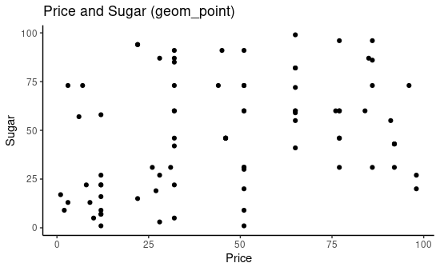

```r
ggplot(candy, aes(x = price_percentile, y = sugar_percentile)) +
  geom_point() + labs(title = "geom_point") +
  labs(x = "Price", y = "Sugar", title = "Price and Sugar (geom_point)") +
  theme_classic()
```

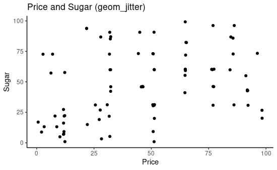

```r
ggplot(candy, aes(x = price_percentile, y = sugar_percentile)) +
  geom_jitter() +
  labs(x = "Price", y = "Sugar", title = "Price and Sugar (geom_jitter)") +
  theme_classic()
```

When one of your numerical variables is a date, instead of scatterplots, you’ll typically use a line graph (i.e., a time series). This can be done with `geom_line()` and to show the individual data points, a point layer can also be added.

```r
#Load Data
load("data/anita.RData")
```

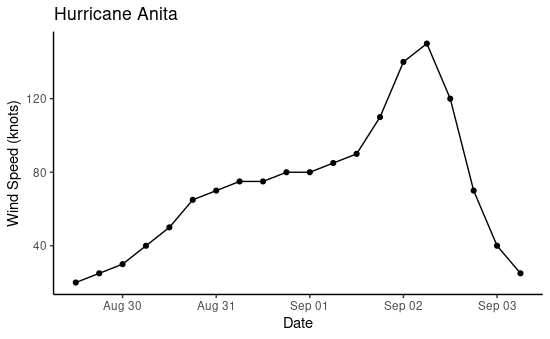

```r
#Time Series
ggplot(anita, aes(x = timestamp, y = wind)) +
  geom_line() + geom_point() +
  labs(x = "Date", y = "Wind Speed (knots)", title = "Hurricane Anita") +
  theme_classic()
```

## Further Styling

Colors can be applied using pre-defined color names present in R/ggplot or using hex codes. When using pre-defined names, these colors will appear in the code editor as the actual color without needing to re-make your graph. In the instance below, note that color is not be used with `aes()`, so colors are not being mapped to specific parts of the data, rather to the entire jitter graph.

The size of points can be changed similarly, by specifying a number representing the size of points. Shape similarly uses numbers in place of shape names to change the same of points. Some basic shapes can also be used by name, such as “triangle”. Some shapes have a fill parameter which allows you to specify a secondary color to fill the interior of the shape with, using the primary color as the border.

Line graphs have a line type that can be changed, as well as a line width similar to points. You can also add horizontal/vertical lines with `geom_hline()` and `geom_vline()`. These can be used to mark a division in the data, such as the point where wind speeds become classified as hurricanes.

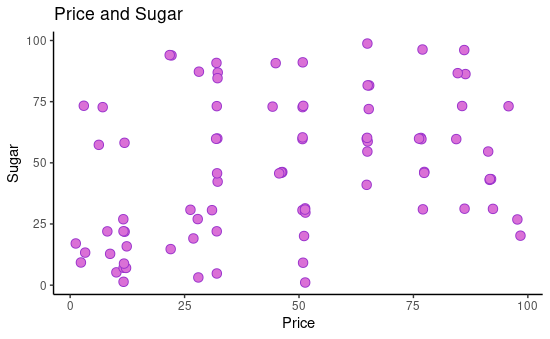

```r
ggplot(candy, aes(x = price_percentile, y = sugar_percentile)) +
  geom_jitter(color = "darkorchid",
              size = 3,
              shape = 21,
              fill = "orchid") +
  labs(x = "Price", y = "Sugar", title = "Price and Sugar") +
  theme_classic()
```

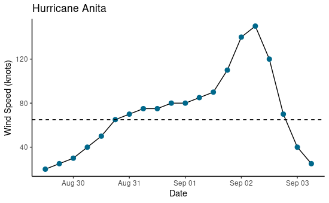

```r
#Time Series
ggplot(anita, aes(x = timestamp, y = wind)) +
  geom_line(linewidth = 0.5) +
  geom_point(color = "deepskyblue4", size = 2.5) +
  geom_hline(linetype = 2, yintercept = 65) +
  labs(x = "Date", y = "Wind Speed (knots)", title = "Hurricane Anita") +
  theme_classic()
```

# 6. Testing Programs

## Exceptions & Warnings

Exceptions in programming occur when something exceptional (usually unexpected) occurs in a program. When writing programs, functions, etc., its important to control for exceptions and handling them when they occur. For example, when writing a function to find the average value of a vector, we expect the user to input numeric values. If this isn’t the case, an exception is raised, so to prevent this, we can handle the error by returning `NA` in that instance.

Because a return value of `NA` might not be expected in this instance, adding a warning message to the user could be beneficial. This can be done with `message()`, though this is typically used for non-exception behavior, such as informing the user of the progress of functions that take longer than average to run. Instead, we can use `warning()` to show there’s a level of severity to the message.

One level higher in severity than warnings is errors. With warnings, the program will continue to progress, but the user is informed, but the program will instead stop when an error is encountered. To raise an error, the `stop()` function is used.

```r
#Average w/ Warning
average <- function(x) {
  if (!is.numeric(x)) {
    warning("`x` must be a numeric vector. Returning NA instead.")
    return(NA)
  }
  sum(x) / length(x)
}

average(c("1","2","3"))
```

```
Warning in average(c("1", "2", "3")) :
  `x` must be a numeric vector. Returning NA instead.
```

```
[1] NA
```

```r
#Average w/ Stop/Error
average <- function(x) {
  if (!is.numeric(x)) {
    stop("`x` must be a numeric vector.")
  }
  sum(x) / length(x)
}

average(c("1","2","3"))
```

```
Error in average(c("1", "2", "3")) : `x` must be a numeric vector.
```

```r
#Average w/ Stop & any NA check
average <- function(x) {
  if (any(is.na(x))) {
    warning("`x` contains one or more NA values. Returning NA.")
    return(NA)
  }
  if (!is.numeric(x)) {
    stop("`x` must be a numeric vector.")
  }

  sum(x) / length(x)
}

average(c(1, 2 ,3))
```

```
[1] 2
```

```r
average(c(1, 2 ,3 , NA))
```

```
[1] NA
```

## Unit Tests

Unit tests are a method of testing the efficacy of functions, especially as they are actively being developed. By convention, tests are done in separate file named in the format `test-funcname.R`. These tests typically give specific inputs with an expected outcome to functions and give feedback on if the function has “passed” the test. To avoid pasting entire functions into the same file as these tests, the function `source()` can be used to call functions from other files. In essence, this imports the function to the current code file.

Note: due to these notes being taken in a markdown file, there is no source to pull the `average()` function from, but below is the code as if this file was being used.

```r
#source("average.R")

test_average <- function() {
  if (average(c(1,2,3)) == 2) {
    cat("`average` passed test\n")
  } else {
    cat("`average` failed test\n")
  }
  if (average(c(-1,-2,-3)) == -2) {
    cat("`average` passed test\n")
  } else {
    cat("`average` failed test\n")
  }
  if (average(c(-1,0,1)) == 0) {
    cat("`average` passed test\n")
  } else {
    cat("`average` failed test\n")
  }
}

test_average()
```

```
`average` passed test
`average` passed test
`average` passed test
```

Because you’ll typically have a large number of test cases, rather than writing like the chunk code above over and over, the testthat library can be used to test your code. Within testthat is the function `test_that()`, which takes a description of the test as its first argument and test cases as the second.

Within the second argument, within brackets each case is defined with a function describing the expected behavior. One of these, `expect_equal()` tests that the value resulting from the defined case is equal to a certain value. There are also more specific functions, such as those that check for warnings (`expect_warning()`) or no warning (`expect_no_warning()`).

```r
#Install and Load testthat
install.packages("testthat")
library(testthat)
```

```r
#source("average.R")

#Test Numerical Inputs Cases
test_that("`average` calculates mean", {
  expect_equal(average(c(1,2,3)), 2)
  expect_equal(average(c(-1,0, 1)), 0)
  expect_equal(average(c(-1,-2,-3)), -2)
  expect_equal(average(c(-2,-1,1,2)), 0)
  expect_equal(average(c(0.1,0.5)),0.3)
  expect_equal(average(c(0.1,0.5)), 0.3, tolerance = 1e-8)
})
```

```
Test passed 🎊
```

```r
#Test Warnings Cases
test_that("`average` warns about NAs in input", {
  expect_warning(average(c(1,NA,3)))
  expect_warning(average(c(NA,NA,NA)))
})
```

```
Test passed 🥳
```

```r
#Test Return NA Cases
test_that("`average` returns NA with NAs in input", {
  expect_equal(suppressWarnings(average(c(1,NA,3))), NA)
  expect_equal(suppressWarnings(average(c(NA,NA,NA))), NA)
})
```

```
Test passed 🌈
```

```r
#Test Error Cases
test_that("`average` stops if `x` is non-numeric", {
  expect_error(average(c("1","2","3")))
  expect_error(average(c("quack!")))
})
```

```
Test passed 🥳
```

## Development Philosophies

Test-driven development (TDD) is a development philosophy focused around the use of tests as the driver of development. In this philosophy, tests are created before writing code and determines what the potential outputs, errors, warnings, etc. will be in the code that will be created. This method allows developers to have well defined goals and can help identify edge cases early on. Behavior-driven development (BDD) was developed from TDD with a greater focus on the actual behavior of programs. BDD uses more descriptive language for tests and attempts to provide more context for how, why, and what to do if a test fails.

## Test Converage

Test coverage is metric used to describe how much of a codebase is covered by tests as well as how many successfully past tests.

# 7. Packaging Programs

## Creating Packages

Packages in R are distributed as single binary files, typically downloaded from the CRAN. Most programs (but not all) are actually initially written in R, and later compiled into these files. These initial program files are called source code. When writing source code, all program files go within a single directory. For the sake of these notes, code snippets will be written in this markdown file and also added to the `ducksay` folder.

```r
#Create Package Directory
dir.create("ducksay")
```

## Package Structure

Each R package will have the same general file structure within them:

`DESCRIPTION`

- Describes the package: who made it, current version number, etc.

`NAMESPACE`

- Defines the functions an end user will be able to interact with from your package.

`man/`

- A folder containing documentation for functions in the package (“man” for “manual”).

`R/`

- R files with actual program code.

`tests/`

- Code for program tests.

`...`

- Other folders and files not necessary, but included in more advanced packages.

```r
#Create Basic Files and Directories
#file.create("ducksay/DESCRIPTION")
#file.create("ducksay/NAMESPACE")
dir.create("ducksay/man")
#dir.create("ducksay/R")
dir.create("ducksay/tests")
```

## Descriptions

WIthin the `DESCRIPTION` file, there is a set of values required that describe specific aspects of your package.

“Package” - Name of the package. This is the name used when using functions such as `install.packages()`. This cannot include capitals, spaces, etc.

“Title” - Title of your package. This can be different than the name with capitals, spaces, etc.

“Description” - What the package does, its use cases, etc.

“Version” - Current version of the package.

“Authors@R” - Who(m) wrote the package and what their role was.

“License” - Legal terms of use for the code included in the package.

```r
write(x =
'Package: ducksay
Title: Ducksay
Description: Say hello with a duck.
Version: 1.0
Authors@R: person("Tanner","Hammond", role = c("aut","cre", "cph"))
License: MIT + file LICENSE',
  file = "ducksay/DESCRIPTION")
```

Above, the basic information required in a `DESCRIPTION` file was added. In this, the function `person()` was used to denote the author/creator of the package. For the License value, the MIT License was used, with added information included in a file called `LICENSE`.

```r
file.create("ducksay/LICENSE")
write(x =
'YEAR: 2024
COPYRIGHT HOLDER: ducksay authors',
  file = "ducksay/LICENSE"
)
```

## Package Code

All R code files for the main body of the function will be within the `R` folder. Below, a new R file is created in this folder, with the following function defined in it.

```r
#Create R File
file.create("ducksay/R/ducksay.R")
```

```r
write(
'ducksay <- function(phrase = "hello, world") {
  paste(
    phrase,
    ">(. )__",
    " (____/",
    sep = "\n"
  )
}',
  file = "ducksay/R/ducksay.R")
```

## Namespaces

The `NAMESPACE` file determines what a user can access as a function in your package. Within this file, we use the `export()` function to say that ducksay is available outside of the package’s internal namespace.

```r
write(x = "export(ducksay)", file = "ducksay/NAMESPACE")
```

## Documentation

To access documentation within R, a question mark is placed before the function you want to get information for (`?ducksay`). Documentation is written in the `man` folder using R’s markup format.

`\name{}` - Name of the function.

`\alias{}` - Alias the function can be called with using `?`.

`\title{}` - Title of the function.

`\description` - Description of what the function does, etc.

```r
#Create Documentation File
file.create("ducksay/man/ducksay.Rd")
```

```r
#Add Documentation
write(
"\\name{ducksay}
\\alias{ducksay}
\\title{Duck Say}
\\description{A duck that says hello}",
  file = "ducksay/man/ducksay.Rd"

)
```

## Building Packages

Source code can be built into binary files through a few methods. First, `build()` is a devtools function or `R CDM build`, a base R command. `build()` is used within R itself, while `R CMD build` is used within the terminal. The files that are created from this use the `.tar.gz` file extension (“tarballs”), which is essentially a zip file format.

```r
#Build Package
library(devtools)
setwd('ducksay')
build()
```